# Local regression in R

Alessio Assuelli, Wael Gafaiti & Alexandre Monti

11/30/2022

## Chapter 0 : Motivation

A lot of different R packages contain functions to perform local regression and each of these functions have a different implementation which will give a different local regression. Each approach has its advantages and inconveniences, and the aim of this project is to summarize the main differences between three of these packages implementing a local regression function.

In chapter 1, we present the theory underlying local regression in order to understand how the local regression functions can be implemented. We continue in chapter 2 by describing the three packages that we compare and we explain how we compare them. In chapter 3, we proceed to the simulation study in order to compare the computation speed and the accuracy of computation depending on different parameters such as the number of points, the bandwidth or the degree of the polynomial used to make the local regression. With this simulation study, we analyze our results and we conclude in chapter 4 by summarizing what we found and which package we recommend to use.

## Chapter 1 : Theoretical bases

The aim of local regression is to approximate the distribution of given data. In order to do that, we fit a polynomial, generally of low-degree, to a subset of the data and we do that at each point of the data. We use weighted least squares to fit the polynomials as we want the points near the point of interest to have more weight than the points far away from the latter and we have recourse to kernel density estimation to get the approximate densities of the data near the point of interest. Thus, parameters such as the degree of the polynomial or the kernel used are adjustable for this method. Let’s see more precisely how linear regression is performed.

Let $(X_1, Y_1), (X_2, Y_2), ..., (X_n, Y_n) \overset{\mathrm{i.i.d.}}{\sim} (X,Y)$ be a random sample. Our aim is to model $m(x) = \mathbb{E}[Y | X= x]$ non-parametrically by just assuming that $m(x)$ is sufficiently smooth. In order to do this, we can use kernel density estimation because $m(x)$ can be written as

$$m(x) = \mathbb{E} \big[ Y \big| X = x \big] = \int_\mathbb{R} y f_{Y|X}(y|x) dy = \frac{\int_\mathbb{R} y f_{X,Y}(x,y) dy}{f_X(x)}$$
Thus, by setting the bandwidth $h$, the kernel $K(\cdot)$ for the density of $X$ and the separable kernel $K(\cdot) K(\cdot)$ for the density of $(X,Y)$, we can make a kernel density estimation and obtain

$$\widehat{f}_X(x) = \frac{1}{nh} \sum_{i=1}^n K\left( \frac{X_i-x}{h} \right) \qquad \& \qquad \widehat{f}_{X,Y}(x,y) = \frac{1}{n h^2} \sum_{i=1}^n K\left( \frac{X_i-x}{h} \right) K\left( \frac{Y_i-y}{h} \right)$$

which can be use to obtain an estimate value of $m(x)$ :

$$\widehat{m}(x) = \frac{\int_\mathbb{R} y \widehat{f}_{X,Y}(x,y) dy}{\widehat{f}_X(x)} = \frac{\int_\mathbb{R} y \frac{1}{n h^2} \sum_{i=1}^n K\left( \frac{X_i-x}{h} \right) K\left( \frac{Y_i-y}{h} \right) dy}{\frac{1}{nh} \sum_{i=1}^n K\left( \frac{X_i-x}{h} \right)} = \frac{\frac{1}{n h^2} \sum_{i=1}^n K\left( \frac{X_i-x}{h} \right) \int_\mathbb{R} y K\left( \frac{Y_i-y}{h} \right) dy}{\frac{1}{nh} \sum_{i=1}^n K\left( \frac{X_i-x}{h} \right)}$$

$$= \frac{\sum_{i=1}^n K\left( \frac{X_i-x}{h} \right) \cdot \frac{1}{h} \int_\mathbb{R} y K\left( \frac{Y_i-y}{h} \right) dy }{\sum_{i=1}^n K\left( \frac{X_i-x}{h} \right)} = \frac{\sum_{i=1}^n K\left( \frac{X_i-x}{h} \right) \int_\mathbb{R} (Y_i + th) K(t) dt}{\sum_{i=1}^n K\left( \frac{X_i-x}{h} \right)} = \frac{\sum_{i=1}^n K\left( \frac{X_i-x}{h} \right) Y_i}{ \sum_{i=1}^n K\left( \frac{X_i-x}{h} \right)}$$
This estimator is called local constant regression and can be used to estimate $m(x)$ at a fixed $x$. This estimator is also a weighted average, which means that it can be viewed as a solution of a weighted least squares problem, i.e.

$$\widehat{m}(x) = \underset{\beta_0 \in \mathbb{R}}{\mathrm{arg \; min}} \sum_{i=1}^\infty K\left( \frac{X_i-x}{h} \right) (Y_i - \beta_0)^2$$

Now, by assuming that $m(x)$ is locally p-times differentiable, we can write the following Taylor series expansion :

$$m(X_i) \approx m(x) + (X_i-x) m'(x) + \frac{(X_i-x)^2}{2!} m''(x) + \ldots + \frac{(X_i-x)^p}{p!} m^{p}(x)$$
This means that we can approximate the conditional expectation $\mathbb{E}[Y | X=x]$ locally by a polynomial of degree $p$. Again, by using kernel density estimation, we can find an estimator of all the $m(x), m'(x), ..., m^p(x)$ by solving the following least squares problem :

$$\begin{equation}
\widehat{M}(x) = (\widehat{m}(x),\ldots, \widehat{m^p}(x)) = \underset{\mathbf{b} \in \mathbb{R}^{p+1}}{\mathrm{arg \; min}} \sum_{i=1}^n [Y_i - \beta_0 - \frac{\beta_1}{1!}(X_i-x) - \ldots - \frac{\beta_p}{p!}(X_i-x)^p]^2 K\left(\frac{X_i-x}{h}\right) \quad (1)
\end{equation}$$

Thus, the local regression method allows one to find a function $\widehat{m}(x)$ that will give an approximation of the distribution of a random sample by using weighted least squares and kernel density estimation.

## Chapter 2 : Packages and comparison

### Chapter 2.1 : Main structure of the packages

In this first part, we give the main structure of the three different packages we focus on. We state the main differences on the algorithms to perform the local regression on a whole domain, i.e. what is the shape of the evaluation set (we will see that one of the selected packages uses a particular trick), which method is used to derive the $\beta$’s in equation $(1)$, and what are the particularities of those packages.

These specifications will help us to better understand the future results, which will be analyzed in the next chapters. In fact, it already gives us an idea of the time of computation and of the goodness of the approximations on specified points.

**Locfit**

*Idea of the local regression algorithm*

The authors of the *locfit* package were inspired by the LOESS and LOWESS packages. In fact, it slightly differs in the evaluation set. They choose to minimize the size of the latter. Thus, it requires less computation of local regression. Then, the remaining points are approximated by interpolation. We should not forget that, in the case of the interpolation, we know more than the coordinates of the points on which we interpolate. We also know the shape of the curve around those ones. It then improves the approximations and the cost of computation, since the computations related to interpolation are cheaper in terms of computation time than those related to local regression. Thus, this algorithm tries to optimize as well the size of the initial set of the evaluation points for a particular bandwidth and kernel. In fact, the size of the evaluation set depends strongly on the chosen bandwidth, since the interpolation follows a tree-structure. Actually, if we take a look at the cost of computation of the local regression on a given point, we can see that it performs the Newton-Raphson algorithm to derive the maximizer of a local likelihood.

*Particularity of the package*

This package is a complete package in the sense that it provides some complementary functions like an implemented cross validation function or a function which returns some additional parameters (like weights, …). This allows one to perform a complete analysis on any given dataset which is quite useful.

**Lpridge**

*Idea of the local regression algorithm*

The *lpridge* algorithm proposes another approach to compute the local regression at given points. At first glance, it seems that this package focuses more on having a fast and stable algorithm to evaluate local polynomial regression on the given points. In fact, without going into details, they “update” the equation they are working with at each step, which leads to less numerical instability and time of computation. When we talk about the stability of the algorithm, it means that even for very low bandwidth, the approximation works well. Now, if we go back to the methods of prediction, it computes the local polynomial regression for the $n$ points of the dataset, and from that, it uses a Taylor expansion to predict the remaining wanted evaluation points.

We recall here that this package allows us to compute a ridge local regression, which means that we can control the smoothness of our local regression by penalizing the coefficients or the derivatives.

*Particularity of the package*

In this package, we only find two implemented functions: *lpridge* and *lpepa*, where *lpepa* is basically *lpridge* without the ridge constraint. In fact, this package is more than a “local regression” package since we can perform a local regression with a penalty cost on the coefficients.

**Locpol**

This package is less documented than the two others. The main theoretical approach is close to the previous ones, but it seems that it does not use complex methods to compute faster steps of the approximation. In fact, we could see Cholesky decomposition in *lpridge*, or the k-structure tree of the evaluation set in *locfit* while here, it computes the inverse of some particular matrices with the standard R implementation (i.e. *solve()*) which is quite expansive in terms of computation time. Nevertheless, it remains difficult to have an overview of the exact algorithm used because of the lack of documentation for this package.

*Particularity of the package*

The *locpol* package contains plenty of functions which are, in fact, used in the main function, i.e. *locpol*. Thus, in practice, there is one main function and the other ones allow us to have a better understanding of what is actually done.

### Chapter 2.2 : Comparison method

Now that we have the general ideas of what is done in these packages, we want to compare their performances. In the first place, we derive their (mean) time of computation and their (mean) accuracy when we apply the local regression on a generated and on a real dataset, and compare them to each other. But in order to have an exact comparison, we impose the arguments to be equal, i.e. taking the same arguments (same bandwidth, same degree, same kernel) and then predict the fitted points on the same evaluation set.

Concerning the accuracy, we compute it in different ways in the simulated and real data. For the simulated data, we compute the accuracy by mean squared error on $100$ uniform points since we know the true function from which the observations were generated. For the real data, we can only compute the mean squared error on the dataset by using cross- validation since we ignore the true function.

**Details on simulated data**

*Size of the dataset*

We first compute the mean computation time and mean computation accuracy for the three packages for different sizes of dataset. In order to do this, we need to set the other parameters :

- the bandwidth is set to $h=6$,
- the degree is set to $p=3$,
- the kernel is set to *Epanechnikov*.

*Choice of bandwidth*

For the comparison of the mean computation time and the mean computation accuracy with the choice of bandwidth, we have to be particularly careful in order to not get lost in the arguments of these functions. Indeed, many functions in *R* use some $\alpha's$ in order to replace the role of the bandwidth. Since we want to compare them properly, we use the bandwidth as seen in the first chapter. For *locpol* and *lpridge*, the argument “bandwidth” can be directly use. But, for *locfit*, we have to give the bandwidth in vector form, with $0$ as first coordinate and the wanted bandwidth as the second one. To ensure a proper comparison, we fixed the following parameters :

- the kernel is again set to *Epanechnikov*,
- the degree is set to $p=3$,
- and the size of the dataset is set to $n=100$.

*Choice of degree*

The degree is an important parameter in the local regression since it will determine locally the variability of the regression. Thus, the degree is a natural number and we will see that it does not need to be higher than $3$ to be efficient. In fact, by taking a too large degree, we increase the variability and then loose in accuracy. To make the comparison proper, we set :

- the kernel to *Epanechnikov*,
- the bandwidth to $h=10$,
- and the size of the dataset to $n=100$.

**Details on real data**

Concerning the real data, we follow the same procedure as the one with simulated data, but we omit the section “Choice of the size of the dataset” since the dataset is real and thus, the size is set. We specify here the value of the different other parameters :

*Choice of bandwidth*

- the kernel is again set to *Epanechnikov*,
- the degree is set to $p=3$.

*Choice of degree*

- the kernel is again set to *Epanechnikov*,
- the bandwidth is set to $h=6$.

*Remark*

All the values of the fixed parameters have been chosen to make proper comparisons and readable plots.

## Chapter 3 : Simulation study

The aim of this chapter is to find the main differences between the three packages that we selected. In order to do this, we study the packages on simulated data and on real data. We begin by comparing the packages on simulated data for the computation speed depending on the number of generated points, the bandwidth and the degree of the fitted polynomial. We then compare the computation precision depending on the same parameters. Finally, we compare the packages on real data by computing the computation speed as well as the computation precision depending on the choice of bandwidth and the degree of the fitted polynomials.

### Chapter 3.1 : Computation speed and accuracy on simulated data

The data are created as follows : first, we choose the observed abscissa $X$ to follow a $U(0,\lfloor \frac{N}{3}\rfloor)$, where $N$ is the number of data. The true function is $f(x)=A+B\cdot x+C \cdot \sin(D \cdot x)+E \cdot \cos(F \cdot x)$. The coefficients $\{A,B,C,D,E,F\}$ are random and

- $A \sim N(0,5)$,
- $B \sim N(0,3)$,
- $C \sim N(0,50)$,
- $D \sim N(0,\frac{1}{6})$,
- $E \sim N(0,20)$ and
- $F \sim N(0,\frac{1}{5})$.

We then create some noise around the true function. The noise follows a $N(0,\sigma)$ with $\sigma \sim N(1,50)$. As the true function is random and the variance of the noise is random too, we can test the packages with different form of functions and different variances. As we know the true function, we are able compute the error accurately. The errors are computed on 100 points. On these points we compute the squares of the differences between the estimated points and the true points and then take the mean of these errors. This will be an estimate of the computation accuracy. The computation time is computed thanks to the function *Sys.time()*.

We begin with the computation speed and accuracy depending on the number of generated data. We compute it for datasets of 10, 50, 100, 500, 1000 and 1500 observations. We set the bandwidth to 6 and the degree of the fitted polynomial to 3. In order to have good approximations of the computation speed and accuracy of the three packages, we compute the mean of the latters for 100 different generated datasets.

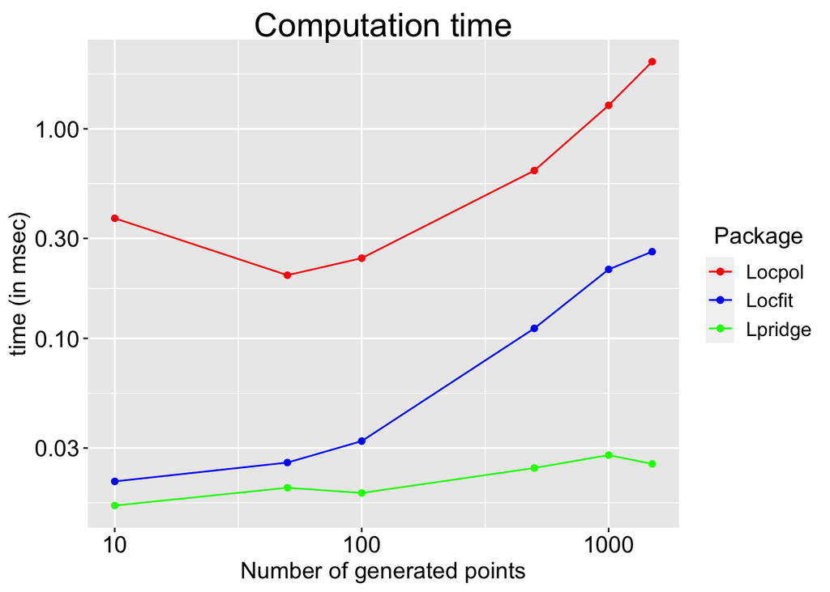

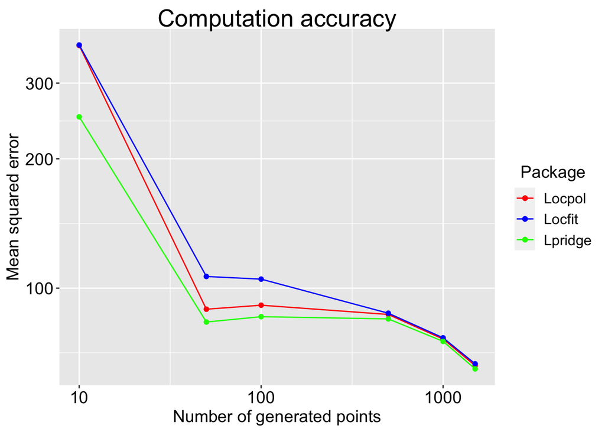

**Time**

We observe the following ranking (from the fastest to the slowest) : *1. lprige, 2. locfit, 3. locpol* and this ranking is stable through the number of points in the dataset. Based on what was stated in *Chapter 2*, it is not astonishing to observe *locpol* in this position, since it has not been implemented to be the fastest. The gap between *lpridge* and *locfit* is smaller than the one between *locfit* and *locpol*. Now, let’s focus on the difference between *locfit* and *lpridge*. Since *lpridge* is faster than *locpol*, it implies that the method of evaluating the local regression on a smaller set is not faster than computing in a optimal way the local regression on the $n$ points. We observe this phenomena even if $n$ is relatively large (i.e. $n=1500$).

**Accuracy**

Concerning the accuracy, we find a different ranking (from the most accurate to the less one) : *1. lpridge, 2. locpol, 3. locfit* and this ranking is stable trough the number of points in the dataset. *Lpridge* is the best again, which is quite impressive. The “fast and stable” seems to have been well implemented.

The three curves follow the same shape. It is difficult to draw exact conclusion on the shapes since we plot these at a logarithmic scale. We note that, looking at the *locfit* accuracy, the method of interpolation seems to be less accurate than the standard method. In fact, when $n=50$, we loose $\approx 17 \%$ of accuracy by using the interpolation method instead of the standard one which is non-negligible.

We can now analyze the computation speed and accuracy depending on the choice of bandwidth. We compute them for bandwidth between 3 and 15. We set the number of generated observations to 100 and the degree of the fitted polynomials to 3. Again, we simulate 100 datasets and take the mean computation duration and accuracy in order to have good approximations of the real computation time and accuracy for the three packages. We find the following results :

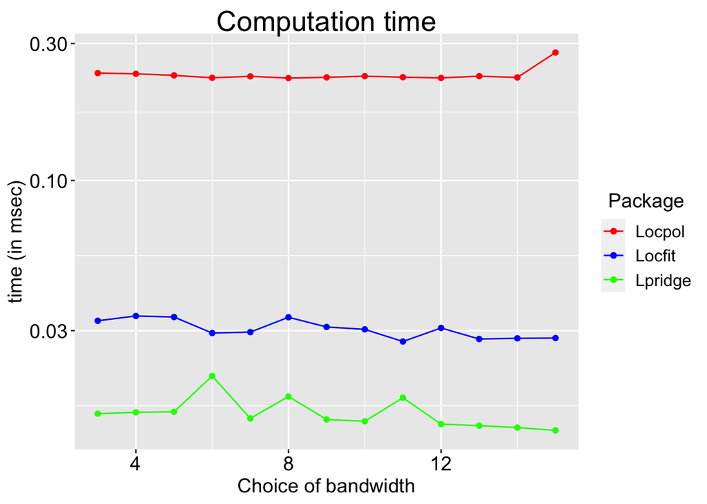

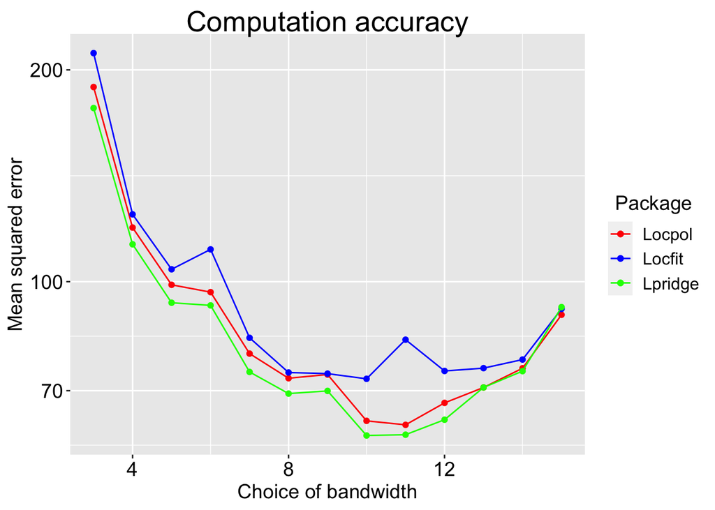

**Accuracy**

For the computation accuracy, *locfit* is the worst of the three algorithms and seems less stable. *Locpol* and *lpridge* are in parallel but *lpridge* is a little bit better. From $h = 12$, the mean squared errors are worse and worse. This comes from the fact that the range of $X$ is 33 for the abscissa and thus, it seems not really appropriate to take a bandwidth of more than $15$. At $h = 15$, *lpridge* is not the best anymore. The best bandwidths are $10$ or $11$ depending on the package. $10$ seems to be the best bandwidth. Thus, we will keep 10 as a bandwidth for the next tests.

The last parameter that we can modify is the degree of the fitted polynomials. We then compute the computation speed and accuracy depending on the latter. We take degree of polynomial from 1 to 5 and we set the number of generated data to 100 and the bandwidth to 10. We take the mean computation time for 100 generated datasets.

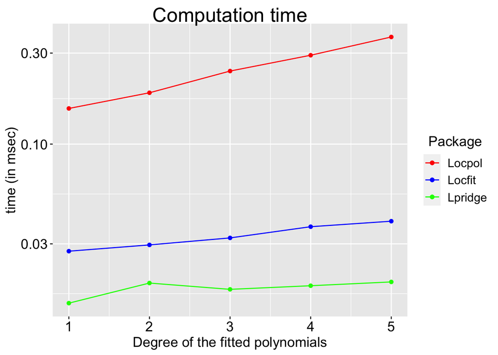

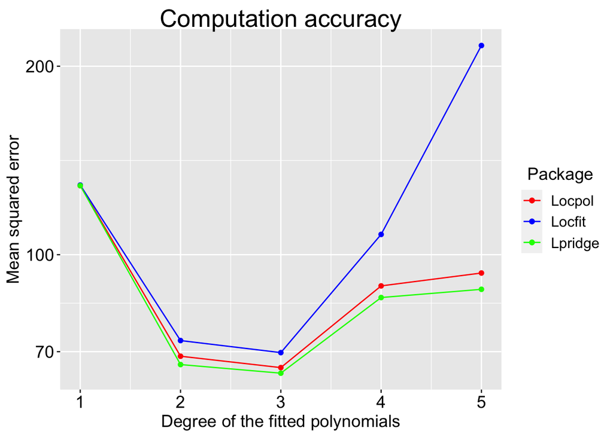

**Time**

Again, the fastest package is *lpridge*, followed by *locfit* and *locpol*. We can see that *locpol* takes more time when the degree increases as well as *locfit* and *lpridge* but the increase in computation time is not as important for the latters.

**Accuracy**

As before, *lpridge* and *locpol* look the same for the accuracy, but *lpridge* is a bit better. All the three functions get better as the degree increase up to 3 and then get worse. The decrease in accuracy for *locfit* is more important than the others.

### Chapter 3.2 : Computation speed and accuracy on real data

Now that we have a better overview of the computation speed and accuracy for our three packages on simulated data, we would like to know if the same conclusions hold on real data. Indeed, it could be that our analyses and conclusions were true only because we took too simple functions. In order to do this, we take data from the *mcycle* package and we take only observations with $time \leq 40$. We then make 100 iterations for each package and we take the mean of the computation speed and the computation accuracy to find the mean computation speed and the mean computation accuracy for the three packages. As before, we compute the computation time and the computation accuracy depending on the choice of bandwidth and the degree of the fitted polynomials.

For the computation time and accuracy depending on the choice of bandwidth, we set the degree of the fitted polynomials to 3.

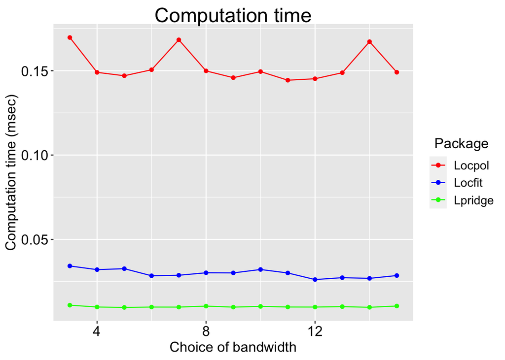

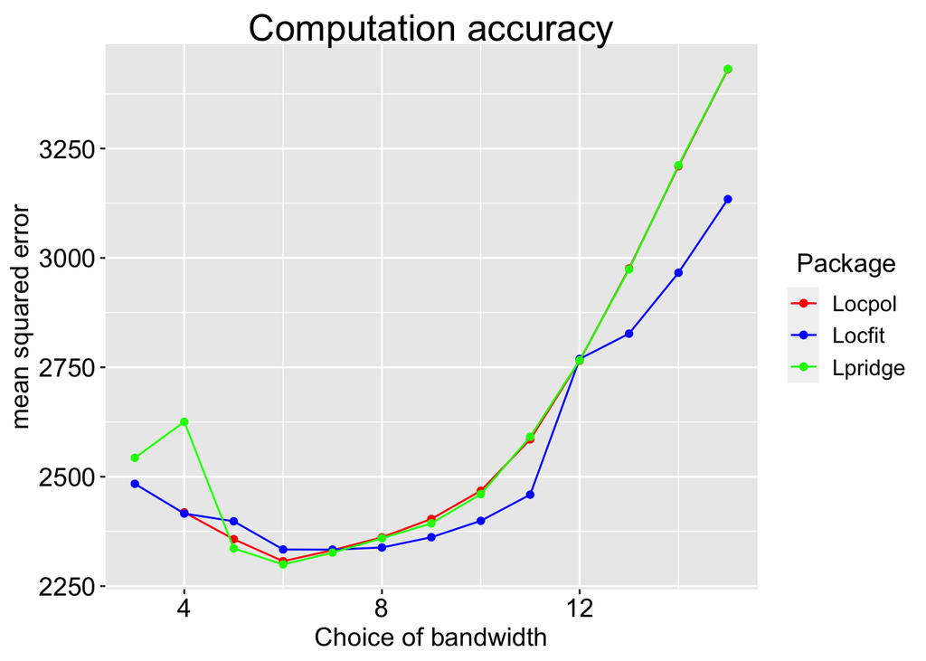

**Time**

We see that the package *locpol* is not stable for the time, and the two others do not depend on the bandwidth. As before, *locpol* is the slowest, *lpridge* is the fastest and *locfit* is close to the computation time of *lpridge* but is a bit slower.

**Accuracy**

It seems that *locpol* does not work very well for low bandwidths.Indeed, for $h=3$, *locpol* returns an $NA$ value which explains why the *locpol* curve has no result for this choice of bandwidth. For bandwidths between 6 and 8 the three packages are almost as good as each other. *Lpridge* hits the overall minimum at $h = 6$. For bigger bandwidths, *locfit* becomes better. Thus, for good bandwidths, i.e. bandwidths between 6 and 8 in our case, *lpridge* is the best as before. On the other hand, *locfit* is the best for bigger bandwidths. *Locpol* and *lpridge* are again almost equal. We can see that the computation accuracy for all three functions gets really worse when the bandwidth becomes greater than $8$.

For the computation time and accuracy depending on the degree of the fitted polynomials, we thus set the bandwidth to 6. The results are summarized in the following plot :

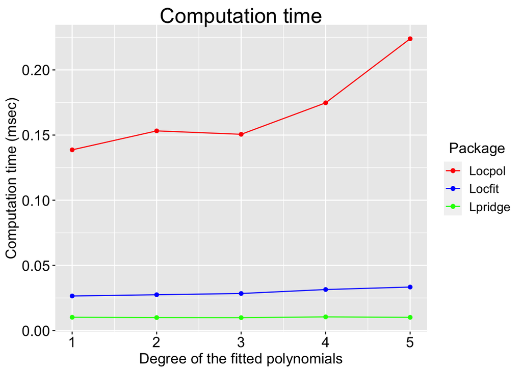

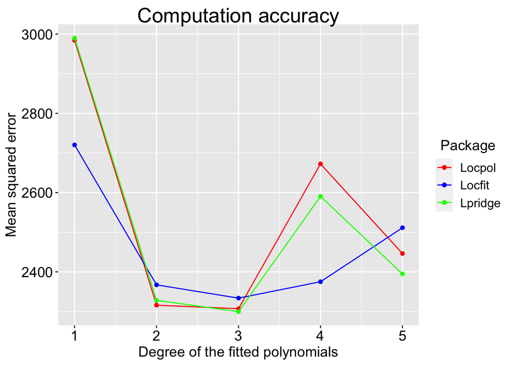

**Time**

Same conclusion as usual, *locpol* is always slower and *lpridge* is a little bit faster than *locfit*. The computation time is pretty stable for these two packages but for *locpol*, the time is very jumpy which highlights the instability of this function. In fact, this package does not use particular method to avoid instability and improve the performance.

**Accuracy**

In fact, here, the situation is slightly different. When the degree is higher than $3$, we overfit our data (there is no penalty for the overfitting in those functions), and thus, the predictions have a higher variance.

### Chapter 3.3 : Computation speed and accuracy without constraint

Until now, we have set constraints such as choice of bandwidth or degree of fitted polynomials in order to compare the three packages under the exact same conditions. But for the purpose of having a full comparison, we also have to let the packages work by themselves which means that we need to compute the computation time and accuracy without constraint. We can do that for the *locfit* and the *locpol* packages, i.e. we can let the packages choose a bandwidth and a degree of fitted polynomials, but *lpridge* force us to choose a bandwidth.

**What are the default choices of bandwidth ?**

We could think that the *locfit* and *locpol* packages could compute a (local) optimal bandwidth w.r.t. to a sort of cross-validation penalty. It is not the case for the both packages. In fact, it chooses a bandwidth based on the range of the dataset. Without going into deep details, let’s see how it is chosen.

In *locpol*, the author decide to separate the dataset in many folds and, over these folds, the bandwidth is fixed to $45\%$ of the range (of the fold). So, there is no will to optimize something.

In *locfit*, the bandwidth is chosen differently. In fact, this is not a bandwidth anymore, it uses the definition of $\alpha$, which computes the local bandwidth $h(x)$ with the following method:

- Compute all the distances: $d(x,x_i) = |x - x_i|$, for all $i\in\{1,...,n\}$.
- Set the bandwidth $h(x)$ to the $k$-th smallest distance, where $k:=\lfloor\alpha n\rfloor$.

Thus, the default “bandwidth” implies more computation for *locfit* than *locpol*.

For *lpridge*, we decided to set the bandwidth to $10\%$ of the range of the abscissa values, which seems to be a coherent choice for a lazy statistician.

**What are the default choices of degree ?**

The *locfit* package sets the default degree of fitted polynomials to $2$ whereas the *locpol* and *lpridge* packages set the default degree of fitted polynomials to $1$.

| Package | Computation speed (in msec) | Computation accuracy |
| --- | --- | --- |
| Locpol | 0.989 | 2553.75 |
| Locfit | 0.032 | 2866.831 |
| Lpridge | 0.02 | 2389.887 |

Once again, *lpridge* is the best for computation speed and accuracy. *Locpol* has a better accuracy than *locfit* but the latter is faster than *locpol*. Thus, it seems that our previous results are still correct, even without setting constraints on the choice of bandwidth and the degree of fitted polynomials.

## Chapter 4 : Conclusions

Overall, we see that the best choice of package is *lpridge*. Indeed, this package is always the fastest and also the most accurate if the choice of bandwidth and degree of fitted polynomials is coherent.

If the *lpridge* package did not exist, the choice of package would depend on what we find the most important between computation speed and computation accuracy. Indeed, if we would a fast package, the *locfit* package would be a clever choice than the *locpol* package. On the other hand, if we are more interested by the computation accuracy, we would rather choose the *locpol* package.

The choice of bandwidth is even more important than the choice of package. Unlike the degree that we should always take to 3, the optimal bandwidth varies depending on the situation. A bad choice of bandwidth can really decrease the accuracy of the the local regression. We thus advise to do a cross validation to obtain the best bandwidth.

To conclude, we can thank Dr. Martin Mächler from the ETHZ to have created the excellent *lpridge* package, thanks to which we do not have to choose between computation speed and computation accuracy ! :-)